# Credit Card Fraud Detection

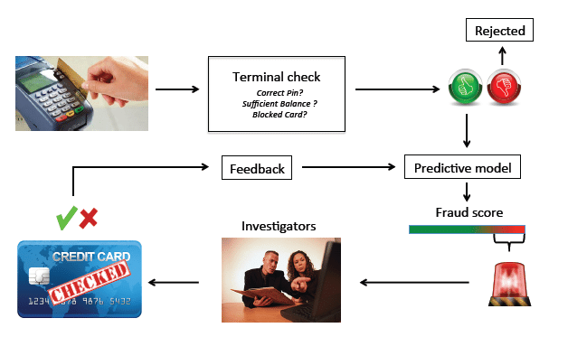

## **Problem Statement:**

- For many banks, retaining high profitable customers is the number one business goal. Banking fraud, however, poses a significant threat to this goal for different banks. In terms of substantial financial losses, trust and credibility, this is a concerning issue to both banks and customers alike.
- In the banking industry, credit card fraud detection using machine learning and deep learning is not only a trend but a necessity for them to put proactive monitoring and fraud prevention mechanisms in place. Machine learning is helping these institutions to reduce time-consuming manual reviews, costly chargebacks and fees as well as denials of legitimate transactions.
- In this project we will detect fraudulent credit card transactions with the help of Machine learning and deep learnig models.
- We will analyse customer-level data that has been collected and analysed during a research collaboration of Worldline and the Machine Learning Group.

## **Theory about Credit Card Fraud**

- **What is Credit Card Fraud Detection?**
  - Credit card fraud is a term that has been coined for unauthorized access of payment cards like credit cards or debit cards to pay for using services or goods
  - Hackers or fraudsters may obtain the confidential details of the card from unsecured websites. When a fraudster compromises an individual's credit/debit card, everyone involved in the process suffers, right from the individual whose confidential data has been leaked to the businesses (generally banks) who issue the credit card and the merchant who is finalizing the transaction with purchase
  - This makes it extremely essential to identify the fraudulent transactions at the onset. Financial institutions and businesses like e-commerce are taking firm steps to flag the fraudsters entering the system. Various advanced machine learning technologies are at play, assessing every transaction and stemming the fraud users in its nip using behavioral data and transaction patterns
  - The process of automatically differentiating between fraudulent and genuine users is known as “credit card fraud detection”
- **How does Credit Card Fraud work?**
  - A credit card is one of the most used financial products to make online purchases and payments such as gas, groceries, TVs, traveling, shopping bills, and so on because of the non-availability of funds at that instance. Credit cards are of most value that provide various benefits in the form of points while using them for different transactions. There are several categories of credit card fraud that are prevalent in today’s time:
    1. Lost/Stolen cards: People steal credit cards from the mail and use them illegally on behalf of the owner. The process of blocking credit cards that have been stolen and re-issuing them is a hassle for both customers and credit card companies. Some financial institutions keep the credit cards blocked until it is verified that the rightful owner has received the card.
    2. Card Abuse: The customer buys goods and items on the credit card but has no intention to pay back the amount charged by the bank for the same. These customers stop answering the calls as the deadline to settle the dues approaches. Sometimes they even declare bankruptcy—this type of fraud results in losses of millions every year.
    3. Identity Theft: The customers apply illegitimate information, and they might even steal the details of a genuine customer to apply for a credit card and then misuse it. In such cases, even card blocking can not stop the credit card from falling into the wrong hands.
    4. Merchant Abuse: Some merchants show illegal transactions (that never occurred) for money laundering. For performing these illicit transactions, legal information of genuine credit card users is stolen to generate replicas of the cards and use it for illegal work.
  - Many traditional old-school techniques have been used since time in-memorial for credit card fraud detection like CVV verification, geolocation tracking, IP Address verification, etc. But over time, the criminals are using more advanced techniques to commit crimes, and it is impossible to prevent them all using only traditional methods. Millions of transactions are processed every second in today’s world, which takes it beyond human intelligence to process all the data to identify the behavioral patterns of the fraudsters. This is where credit card fraud detection using machine learning plays a vital role.
  - Financial institutions increasingly depend upon automated machine learning systems to make intelligent decisions and protect businesses against substantial losses. These measures play a significant role in reducing the risk while doing online transactions. Like humans, machine learning algorithms learn from past transaction data and use that information to analyze future transactions with the same lens. While machines might not be as intelligent as humans are and might need some supervision on top of it, the advantage lies in the speed of data processing and computation. Also, machines can identify and remember more patterns in vast volumes of data compared to humans. Generally, these algorithms are known as anomaly detection. Let us delve into details in the next section.

**Credit Card Fraud Detection using Machine Learning can be done using**

1. **Unsupervised Learning** -
   - Machine Learning Algorithms such as Isolation Forest, One-class SVM, LOF, etc., do not require labeled data for training the model. They identify patterns in the data and try to group the data points based on observed similarities in patterns.
2. **Supervised Learning**
   - Machine Learning and Deep Learning Algorithms such as Ensemble Models (RandomForest, XGBoost, LightGBM, etc.), KNN, Neural Networks, Autoencoders, etc. These algorithms are trained on labeled data, and the model learns to predict the labels for the unseen data. Labeled data can be expensive to gather.

**Challenges in Credit Card Fraud Detection**

- The challenges involved in credit card fraud detection project is primarily the data itself. The data is heavily imbalanced, i.e., the count of data labeled as fraudulent is way less than the data labeled as non-fraudulent data. This makes it extremely tricky to train the model as it tends to overfit for the majority class and underfit for the minority class. Techniques like oversampling, undersampling, cost-sensitive learning, etc. can be used to deal with this. The metrics used for the final model are different from standard evaluation metrics of accuracy, AUC-ROC, etc.
- Another prevalent faced challenge is the quality and quantity of the data. The startups in the early stage do not have much user history data to train extensive models, which makes it difficult to train a robust fraud detection model. A temporary solution to this problem can be sourcing data from an external third party, like scores from credit bureaus.

## **DATASET DESCRIPTION**

- The dataset contains 284,807 transactions among which there are 492 i.e., 0.172% transactions are fraudulent transactions
- It also contains transactions made by a cardholder in 2 days in month of september 2013
- This dataset is highly unbalanced. Due to security reasons, most of the features in the dataset are transformed using principal component analysis (PCA). V1, V2, V3,…, V28 are PCA applied features and rest features include ‘time’, ‘amount’ and ‘class’ are non-PCA applied features
1. Importing dependencies
2. Exploratory data analysis
3. Splitting the data into train & test data
4. Model Building
   - Perform cross validation with RepeatedKFold
   - Perform cross validation with StratifiedKFold
   - RandomOverSampler with StratifiedKFold Cross Validation
   - Oversampling with SMOTE Oversampling
   - Oversampling with ADASYN Oversampling
5. Hyperparameter Tuning
6. Conclusion

## **Importing Dependencies**

```python
# Importing the libraries
import numpy as np
import pandas as pd
import time

import matplotlib.pyplot as plt
%matplotlib inline
import seaborn as sns

from scipy import stats
from scipy.stats import norm, skew
from scipy.special import boxcox1p
from scipy.stats import boxcox_normmax

from sklearn import preprocessing
from sklearn.preprocessing import StandardScaler

import sklearn
from sklearn import metrics
from sklearn.metrics import roc_curve, auc, roc_auc_score
from sklearn.metrics import classification_report,confusion_matrix
from sklearn.metrics import average_precision_score, precision_recall_curve

from sklearn.model_selection import train_test_split
from sklearn.model_selection import StratifiedKFold
from sklearn.model_selection import GridSearchCV, RandomizedSearchCV

from sklearn.linear_model import Ridge, Lasso, LogisticRegression
from sklearn.neighbors import KNeighborsClassifier
from sklearn.linear_model import LogisticRegressionCV
from sklearn.tree import DecisionTreeClassifier
from sklearn.ensemble import AdaBoostClassifier
from sklearn.ensemble import RandomForestClassifier
import xgboost as xgb
from xgboost import XGBClassifier
from xgboost import plot_importance
from sklearn.ensemble import AdaBoostClassifier


from tensorflow.keras import Sequential
import tensorflow as tf
from tensorflow.keras.layers import Dense,Dropout

# To ignore warnings
import warnings
warnings.filterwarnings("ignore")
```

## **Exploratory data analysis**

```python
# Mounting the google drive
from google.colab import drive
drive.mount('/content/drive')
import os
os.getcwd()
path = "/content/drive/MyDrive/Projects/Credit Card Defaulter"
os.chdir(path)
os.getcwd()
```

```
'/content/drive/MyDrive/Projects/Credit Card Defaulter'
```

```python
# Loading the data
df = pd.read_csv('creditcard.csv')
df = df.sample(n=50000)
df.head()
```

|  | Time | V1 | V2 | V3 | V4 | V5 | V6 | V7 | V8 | V9 | ... | V21 | V22 | V23 | V24 | V25 | V26 | V27 | V28 | Amount | Class |
| --- | --- | --- | --- | --- | --- | --- | --- | --- | --- | --- | --- | --- | --- | --- | --- | --- | --- | --- | --- | --- | --- |
| 192316 | 129633.0 | -0.541013 | 1.107931 | -1.774693 | -0.708025 | -0.456628 | -0.295740 | 2.360015 | -0.293290 | -0.597604 | ... | 0.100783 | 0.308628 | -0.177781 | 0.642998 | 0.037229 | 0.494459 | -0.390304 | -0.202842 | 300.00 | 0 |
| 91715 | 63596.0 | -0.627415 | 1.123128 | 1.560804 | -0.076211 | 0.223046 | -0.904104 | 0.938718 | -0.155628 | -0.392705 | ... | 0.067629 | 0.094912 | -0.176009 | 0.359548 | -0.058737 | -0.666741 | -0.019712 | 0.135237 | 4.65 | 0 |
| 140052 | 83511.0 | -0.916656 | 0.996912 | 2.114384 | 1.082337 | -1.104885 | -0.049506 | -0.411277 | 0.755500 | 0.369418 | ... | -0.006409 | 0.077001 | -0.108486 | 0.345586 | -0.031918 | -0.303443 | 0.275835 | 0.123201 | 9.99 | 0 |
| 13800 | 24466.0 | -0.886470 | -0.126264 | 3.551005 | 3.751230 | -0.563369 | 1.141458 | -0.889331 | 0.234025 | 2.022399 | ... | -0.058542 | 0.915166 | 0.376580 | 0.375107 | -0.396255 | 0.368435 | 0.028081 | -0.129019 | 3.80 | 0 |
| 55873 | 47165.0 | 1.223111 | -0.942174 | 0.196413 | -0.420355 | -1.078497 | -0.451728 | -0.572279 | 0.023307 | -0.216677 | ... | 0.099471 | 0.171263 | -0.112221 | 0.065022 | 0.518764 | -0.116556 | -0.004219 | 0.012913 | 80.44 | 0 |

5 rows × 31 columns

```python
# Checking the shape
df.shape
```

```
(50000, 31)
```

```python
# Checking the datatypes and null/non-null distribution
df.info()
```

```
<class 'pandas.core.frame.DataFrame'>
Int64Index: 50000 entries, 192316 to 240041
Data columns (total 31 columns):
 #   Column  Non-Null Count  Dtype
---  ------  --------------  -----
 0   Time    50000 non-null  float64
 1   V1      50000 non-null  float64
 2   V2      50000 non-null  float64
 3   V3      50000 non-null  float64
 4   V4      50000 non-null  float64
 5   V5      50000 non-null  float64
 6   V6      50000 non-null  float64
 7   V7      50000 non-null  float64
 8   V8      50000 non-null  float64
 9   V9      50000 non-null  float64
```

[output cut: 23 more lines]

```python
# Checking distribution of numerical values in the dataset
df.describe()
```

|  | Time | V1 | V2 | V3 | V4 | V5 | V6 | V7 | V8 | V9 | ... | V21 | V22 | V23 | V24 | V25 | V26 | V27 | V28 | Amount | Class |
| --- | --- | --- | --- | --- | --- | --- | --- | --- | --- | --- | --- | --- | --- | --- | --- | --- | --- | --- | --- | --- | --- |
| count | 50000.000000 | 50000.000000 | 50000.000000 | 50000.000000 | 50000.000000 | 50000.000000 | 50000.000000 | 50000.000000 | 50000.000000 | 50000.000000 | ... | 50000.000000 | 50000.000000 | 50000.000000 | 50000.000000 | 50000.000000 | 50000.000000 | 50000.000000 | 50000.000000 | 50000.000000 | 50000.000000 |
| mean | 95027.093240 | 0.006869 | 0.000014 | 0.002052 | 0.006169 | 0.003853 | 0.000950 | 0.004717 | 0.004668 | 0.008224 | ... | 0.003217 | -0.002990 | 0.000050 | -0.002233 | -0.005501 | -0.000519 | 0.004045 | -0.000187 | 88.195327 | 0.001680 |
| std | 47608.097497 | 1.940516 | 1.625471 | 1.504460 | 1.410004 | 1.364510 | 1.322307 | 1.212862 | 1.170605 | 1.091409 | ... | 0.726534 | 0.725087 | 0.601028 | 0.606238 | 0.516719 | 0.485098 | 0.382500 | 0.299191 | 242.872770 | 0.040954 |
| min | 0.000000 | -40.470142 | -42.172688 | -31.103685 | -5.683171 | -40.427726 | -23.496714 | -31.197329 | -50.943369 | -9.462573 | ... | -22.665685 | -8.887017 | -23.222016 | -2.740677 | -4.930750 | -1.664130 | -8.878665 | -8.478686 | 0.000000 | 0.000000 |
| 25% | 54267.750000 | -0.912608 | -0.597673 | -0.883402 | -0.841195 | -0.683034 | -0.763299 | -0.549844 | -0.204852 | -0.636216 | ... | -0.229721 | -0.546591 | -0.160259 | -0.356284 | -0.319768 | -0.328492 | -0.070311 | -0.052419 | 5.500000 | 0.000000 |
| 50% | 85203.000000 | 0.017080 | 0.072429 | 0.176216 | -0.011505 | -0.053596 | -0.270196 | 0.042177 | 0.022762 | -0.046710 | ... | -0.029802 | 0.004218 | -0.009554 | 0.041472 | 0.010167 | -0.054266 | 0.001581 | 0.011351 | 21.550000 | 0.000000 |
| 75% | 139631.500000 | 1.315053 | 0.808100 | 1.024045 | 0.759097 | 0.609536 | 0.399615 | 0.573382 | 0.327584 | 0.607525 | ... | 0.187433 | 0.531716 | 0.149508 | 0.437811 | 0.343418 | 0.237930 | 0.094009 | 0.079463 | 77.000000 | 0.000000 |
| max | 172792.000000 | 2.451888 | 16.713389 | 3.920275 | 12.699542 | 34.099309 | 23.917837 | 44.054461 | 20.007208 | 10.392889 | ... | 27.202839 | 7.220158 | 15.426351 | 3.998294 | 4.828097 | 3.517346 | 12.152401 | 15.374949 | 12910.930000 | 1.000000 |

8 rows × 31 columns

```python
# Checking the class distribution of the target variable
df['Class'].value_counts()
```

```
0    49916
1       84
Name: Class, dtype: int64
```

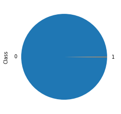

```python
# Checking the class distribution of the target variable in percentage
df['Class'].value_counts(normalize = True).plot.pie()
```

```python
# Checking the correlation
corr = df.corr()
corr
```

|  | Time | V1 | V2 | V3 | V4 | V5 | V6 | V7 | V8 | V9 | ... | V21 | V22 | V23 | V24 | V25 | V26 | V27 | V28 | Amount | Class |
| --- | --- | --- | --- | --- | --- | --- | --- | --- | --- | --- | --- | --- | --- | --- | --- | --- | --- | --- | --- | --- | --- |
| Time | 1.000000 | 0.118292 | -0.012198 | -0.421144 | -0.112760 | 0.177543 | -0.058231 | 0.082175 | -0.032188 | -0.005067 | ... | 0.046404 | 0.147353 | 0.051976 | -0.017890 | -0.239786 | -0.044932 | -0.006478 | -0.011512 | -0.012154 | -0.016079 |
| V1 | 0.118292 | 1.000000 | -0.004389 | -0.009109 | 0.011063 | -0.007697 | -0.001057 | 0.004101 | -0.011941 | 0.005733 | ... | -0.014567 | 0.007841 | 0.040755 | -0.004787 | 0.010659 | -0.006836 | -0.052209 | 0.047343 | -0.221128 | -0.107550 |
| V2 | -0.012198 | -0.004389 | 1.000000 | 0.001119 | 0.009434 | 0.007904 | 0.003128 | 0.022083 | 0.005633 | -0.006709 | ... | 0.022919 | -0.002429 | 0.059792 | -0.000121 | 0.014421 | 0.000852 | -0.037145 | 0.059617 | -0.526473 | 0.085935 |
| V3 | -0.421144 | -0.009109 | 0.001119 | 1.000000 | 0.014623 | -0.009876 | 0.003400 | -0.003018 | -0.008532 | 0.000546 | ... | -0.016443 | 0.015221 | 0.014239 | -0.000074 | -0.002764 | -0.005301 | -0.011037 | 0.013405 | -0.206868 | -0.187882 |
| V4 | -0.112760 | 0.011063 | 0.009434 | 0.014623 | 1.000000 | 0.003917 | -0.006781 | 0.004598 | -0.003612 | 0.003839 | ... | -0.002481 | -0.001170 | -0.016054 | 0.000745 | -0.001209 | -0.001193 | 0.009019 | -0.010950 | 0.085269 | 0.118884 |
| V5 | 0.177543 | -0.007697 | 0.007904 | -0.009876 | 0.003917 | 1.000000 | 0.006577 | 0.004568 | -0.007636 | -0.004547 | ... | -0.018828 | 0.013145 | -0.002647 | 0.000292 | -0.011059 | 0.000032 | 0.013777 | -0.017210 | -0.385417 | -0.098504 |
| V6 | -0.058231 | -0.001057 | 0.003128 | 0.003400 | -0.006781 | 0.006577 | 1.000000 | -0.002341 | 0.019124 | -0.001879 | ... | 0.013933 | 0.000243 | 0.002962 | -0.009796 | 0.001131 | -0.003912 | -0.015692 | 0.013130 | 0.210204 | -0.040388 |
| V7 | 0.082175 | 0.004101 | 0.022083 | -0.003018 | 0.004598 | 0.004568 | -0.002341 | 1.000000 | -0.018584 | -0.020129 | ... | -0.020720 | 0.009716 | -0.015913 | 0.003073 | -0.002654 | -0.003813 | -0.026919 | 0.009925 | 0.390978 | -0.173761 |
| V8 | -0.032188 | -0.011941 | 0.005633 | -0.008532 | -0.003612 | -0.007636 | 0.019124 | -0.018584 | 1.000000 | -0.005950 | ... | -0.054987 | 0.033091 | 0.020526 | -0.008456 | 0.004981 | -0.006505 | -0.020052 | 0.008887 | -0.106148 | 0.031241 |
| V9 | -0.005067 | 0.005733 | -0.006709 | 0.000546 | 0.003839 | -0.004547 | -0.001879 | -0.020129 | -0.005950 | 1.000000 | ... | -0.002835 | 0.009277 | -0.006674 | -0.002013 | -0.011032 | 0.000511 | 0.013312 | -0.021642 | -0.043101 | -0.083785 |
| V10 | 0.030502 | 0.004307 | -0.000151 | 0.000223 | 0.015494 | -0.005913 | 0.003096 | -0.024081 | -0.017924 | -0.030983 | ... | -0.017353 | -0.000331 | 0.002377 | 0.003696 | -0.003346 | 0.004854 | 0.012708 | -0.019358 | -0.099478 | -0.197386 |
| V11 | -0.250578 | 0.000665 | -0.000712 | -0.001009 | -0.002416 | 0.001904 | -0.003124 | -0.000269 | 0.004796 | -0.000142 | ... | 0.002300 | -0.006485 | -0.000117 | -0.002833 | 0.002569 | 0.000449 | 0.002089 | 0.002802 | -0.002800 | 0.144429 |
| V12 | 0.125820 | 0.000583 | -0.002155 | -0.011736 | 0.002873 | -0.000296 | 0.002972 | -0.010803 | -0.006058 | -0.012543 | ... | 0.002496 | 0.003197 | 0.001026 | -0.004147 | 0.000852 | -0.007224 | 0.012033 | -0.004487 | -0.008161 | -0.234321 |
| V13 | -0.062962 | 0.001689 | -0.003999 | 0.002939 | -0.001558 | -0.001034 | 0.003397 | -0.005260 | 0.000664 | 0.004843 | ... | -0.008727 | 0.001335 | -0.004190 | -0.001789 | -0.004900 | 0.002078 | -0.000077 | -0.004109 | 0.006545 | 0.000468 |
| V14 | -0.101219 | -0.003645 | 0.000807 | 0.000297 | 0.003207 | 0.002666 | 0.004044 | 0.002015 | -0.004924 | 0.002770 | ... | -0.008612 | 0.001467 | 0.003836 | 0.000799 | 0.000844 | 0.001969 | -0.005305 | 0.010606 | 0.032959 | -0.270890 |
| V15 | -0.182811 | 0.001768 | 0.002957 | -0.004989 | 0.000194 | -0.003227 | 0.001456 | -0.000049 | -0.003204 | -0.009113 | ... | -0.000029 | -0.001682 | -0.006076 | 0.002694 | 0.008768 | 0.000749 | 0.011544 | -0.006817 | -0.000919 | -0.005552 |
| V16 | 0.015188 | 0.002290 | 0.002878 | -0.001924 | 0.003615 | 0.002571 | -0.008992 | -0.009611 | 0.001285 | 0.000524 | ... | -0.006569 | -0.001318 | -0.003929 | 0.006953 | -0.000389 | 0.010345 | 0.003444 | -0.010813 | -0.011884 | -0.179348 |
| V17 | -0.075270 | 0.003702 | -0.001134 | -0.003380 | 0.010248 | -0.000359 | -0.001768 | 0.001545 | -0.011023 | -0.002319 | ... | -0.021812 | 0.007780 | 0.004943 | -0.001321 | -0.000501 | 0.003339 | -0.009543 | 0.005462 | 0.010560 | -0.304771 |
| V18 | 0.095193 | 0.006327 | 0.003657 | -0.006155 | -0.007904 | 0.002368 | -0.006642 | -0.003419 | -0.003290 | 0.001512 | ... | -0.011524 | 0.009922 | -0.006112 | -0.002160 | -0.004865 | 0.003844 | -0.002958 | -0.001955 | 0.030029 | -0.105167 |
| V19 | 0.028739 | -0.002696 | -0.003370 | -0.002532 | 0.006034 | 0.002800 | -0.011828 | -0.004611 | -0.010370 | 0.003776 | ... | 0.000664 | -0.009657 | -0.007034 | 0.003117 | -0.003531 | -0.007377 | 0.009047 | -0.004321 | -0.051108 | 0.034304 |
| V20 | -0.051428 | 0.019607 | 0.021118 | 0.004534 | -0.006939 | -0.025632 | 0.013653 | 0.037741 | 0.014759 | -0.000393 | ... | -0.004366 | 0.012152 | 0.029424 | 0.005008 | 0.010408 | 0.005749 | -0.036387 | 0.044919 | 0.332523 | 0.014342 |
| V21 | 0.046404 | -0.014567 | 0.022919 | -0.016443 | -0.002481 | -0.018828 | 0.013933 | -0.020720 | -0.054987 | -0.002835 | ... | 1.000000 | 0.020952 | 0.017877 | -0.001753 | 0.004629 | -0.004908 | -0.017734 | 0.022524 | 0.104362 | 0.066410 |
| V22 | 0.147353 | 0.007841 | -0.002429 | 0.015221 | -0.001170 | 0.013145 | 0.000243 | 0.009716 | 0.033091 | 0.009277 | ... | 0.020952 | 1.000000 | -0.004213 | 0.001411 | -0.001968 | -0.001008 | -0.002465 | 0.003759 | -0.068103 | -0.012237 |
| V23 | 0.051976 | 0.040755 | 0.059792 | 0.014239 | -0.016054 | -0.002647 | 0.002962 | -0.015913 | 0.020526 | -0.006674 | ... | 0.017877 | -0.004213 | 1.000000 | -0.003951 | -0.021767 | -0.003337 | -0.055086 | 0.046792 | -0.159856 | 0.003708 |
| V24 | -0.017890 | -0.004787 | -0.000121 | -0.000074 | 0.000745 | 0.000292 | -0.009796 | 0.003073 | -0.008456 | -0.002013 | ... | -0.001753 | 0.001411 | -0.003951 | 1.000000 | 0.005079 | 0.004826 | 0.008047 | -0.001192 | 0.007971 | -0.008032 |
| V25 | -0.239786 | 0.010659 | 0.014421 | -0.002764 | -0.001209 | -0.011059 | 0.001131 | -0.002654 | 0.004981 | -0.011032 | ... | 0.004629 | -0.001968 | -0.021767 | 0.005079 | 1.000000 | 0.003479 | -0.013041 | -0.010587 | -0.047447 | 0.009835 |
| V26 | -0.044932 | -0.006836 | 0.000852 | -0.005301 | -0.001193 | 0.000032 | -0.003912 | -0.003813 | -0.006505 | 0.000511 | ... | -0.004908 | -0.001008 | -0.003337 | 0.004826 | 0.003479 | 1.000000 | -0.007550 | 0.004986 | 0.001026 | 0.002806 |
| V27 | -0.006478 | -0.052209 | -0.037145 | -0.011037 | 0.009019 | 0.013777 | -0.015692 | -0.026919 | -0.020052 | 0.013312 | ... | -0.017734 | -0.002465 | -0.055086 | 0.008047 | -0.013041 | -0.007550 | 1.000000 | 0.073469 | 0.038908 | 0.026460 |
| V28 | -0.011512 | 0.047343 | 0.059617 | 0.013405 | -0.010950 | -0.017210 | 0.013130 | 0.009925 | 0.008887 | -0.021642 | ... | 0.022524 | 0.003759 | 0.046792 | -0.001192 | -0.010587 | 0.004986 | 0.073469 | 1.000000 | 0.010640 | 0.005176 |
| Amount | -0.012154 | -0.221128 | -0.526473 | -0.206868 | 0.085269 | -0.385417 | 0.210204 | 0.390978 | -0.106148 | -0.043101 | ... | 0.104362 | -0.068103 | -0.159856 | 0.007971 | -0.047447 | 0.001026 | 0.038908 | 0.010640 | 1.000000 | 0.008788 |
| Class | -0.016079 | -0.107550 | 0.085935 | -0.187882 | 0.118884 | -0.098504 | -0.040388 | -0.173761 | 0.031241 | -0.083785 | ... | 0.066410 | -0.012237 | 0.003708 | -0.008032 | 0.009835 | 0.002806 | 0.026460 | 0.005176 | 0.008788 | 1.000000 |

31 rows × 31 columns

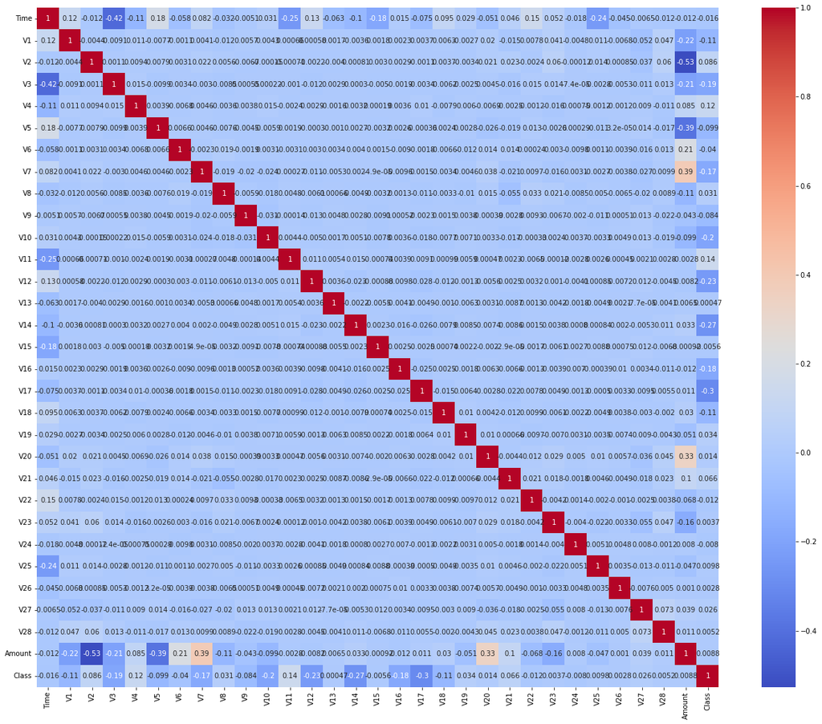

```python
# Checking the correlation in heatmap
plt.figure(figsize=(22,18))

sns.heatmap(corr, cmap="coolwarm", annot=True)
plt.show()
```

Here we will observe the distribution of our classes

```python
# Checking the % distribution of normal vs fraud
classes=df['Class'].value_counts()
normal_share=classes[0]/df['Class'].count()*100
fraud_share=classes[1]/df['Class'].count()*100

print(normal_share)
print(fraud_share)
```

```
99.832
0.168
```

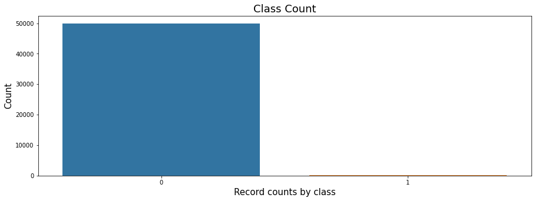

```python
# Create a bar plot for the number and percentage of fraudulent vs non-fraudulent transcations
plt.figure(figsize=(15,5))
sns.countplot(df['Class'])
plt.title("Class Count", fontsize=18)
plt.xlabel("Record counts by class", fontsize=15)
plt.ylabel("Count", fontsize=15)
plt.show()
```

```python
# As time is given in relative fashion, we are using pandas.Timedelta which Represents a duration, the difference between two times or dates.
Delta_Time = pd.to_timedelta(df['Time'], unit='s')

#Create derived columns Mins and hours
df['Time_Day'] = (Delta_Time.dt.components.days).astype(int)
df['Time_Hour'] = (Delta_Time.dt.components.hours).astype(int)
df['Time_Min'] = (Delta_Time.dt.components.minutes).astype(int)
```

```python
# Drop unnecessary columns
# We will drop Time,as we have derived the Day/Hour/Minutes from the time column
df.drop('Time', axis = 1, inplace= True)
# We will keep only derived column hour, as day/minutes might not be very useful
df.drop(['Time_Day', 'Time_Min'], axis = 1, inplace= True)
```

## **Splitting the data into train & test data**

```python
# Splitting the dataset into X and y
y= df['Class']
X = df.drop(['Class'], axis=1)
```

```python
# Checking some rows of X
X.head()
```

|  | V1 | V2 | V3 | V4 | V5 | V6 | V7 | V8 | V9 | V10 | ... | V21 | V22 | V23 | V24 | V25 | V26 | V27 | V28 | Amount | Time_Hour |
| --- | --- | --- | --- | --- | --- | --- | --- | --- | --- | --- | --- | --- | --- | --- | --- | --- | --- | --- | --- | --- | --- |
| 192316 | -0.541013 | 1.107931 | -1.774693 | -0.708025 | -0.456628 | -0.295740 | 2.360015 | -0.293290 | -0.597604 | -0.513867 | ... | 0.100783 | 0.308628 | -0.177781 | 0.642998 | 0.037229 | 0.494459 | -0.390304 | -0.202842 | 300.00 | 12 |
| 91715 | -0.627415 | 1.123128 | 1.560804 | -0.076211 | 0.223046 | -0.904104 | 0.938718 | -0.155628 | -0.392705 | -0.595657 | ... | 0.067629 | 0.094912 | -0.176009 | 0.359548 | -0.058737 | -0.666741 | -0.019712 | 0.135237 | 4.65 | 17 |
| 140052 | -0.916656 | 0.996912 | 2.114384 | 1.082337 | -1.104885 | -0.049506 | -0.411277 | 0.755500 | 0.369418 | -0.500382 | ... | -0.006409 | 0.077001 | -0.108486 | 0.345586 | -0.031918 | -0.303443 | 0.275835 | 0.123201 | 9.99 | 23 |
| 13800 | -0.886470 | -0.126264 | 3.551005 | 3.751230 | -0.563369 | 1.141458 | -0.889331 | 0.234025 | 2.022399 | 0.262257 | ... | -0.058542 | 0.915166 | 0.376580 | 0.375107 | -0.396255 | 0.368435 | 0.028081 | -0.129019 | 3.80 | 6 |
| 55873 | 1.223111 | -0.942174 | 0.196413 | -0.420355 | -1.078497 | -0.451728 | -0.572279 | 0.023307 | -0.216677 | 0.492314 | ... | 0.099471 | 0.171263 | -0.112221 | 0.065022 | 0.518764 | -0.116556 | -0.004219 | 0.012913 | 80.44 | 13 |

5 rows × 30 columns

```python
# Checking some rows of y
y.head()
```

```
192316    0
91715     0
140052    0
13800     0
55873     0
Name: Class, dtype: int64
```

```python
# Splitting the dataset using train test split
X_train, X_test, y_train, y_test = train_test_split(X, y, random_state=1, test_size=0.20)
```

Preserve X_test & y_test to evaluate on the test data once you build the model

```python
# Checking the spread of data post split
print(np.sum(y))
print(np.sum(y_train))
print(np.sum(y_test))
```

```
84
69
15
```

Plotting the distribution of a variable

```python
# Accumulating all the column names under one variable
cols = list(X.columns.values)
```

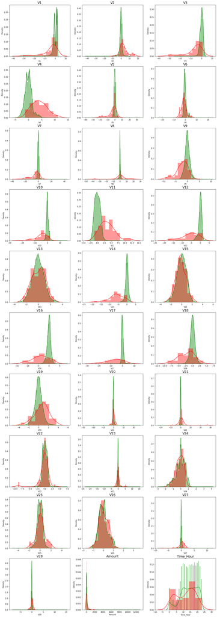

```python
# plot the histogram of a variable from the dataset to see the skewness
normal_records = df.Class == 0
fraud_records = df.Class == 1

plt.figure(figsize=(20, 60))
for n, col in enumerate(cols):
  plt.subplot(10,3,n+1)
  sns.distplot(X[col][normal_records], color='green')
  sns.distplot(X[col][fraud_records], color='red')
  plt.title(col, fontsize=17)
plt.show()
```

## **Model Building**

```python
#Create a dataframe to store results
df_Results = pd.DataFrame(columns=['Methodology','Model','Accuracy','roc_value','threshold'])
```

```python
# Created a common function to plot confusion matrix
def Plot_confusion_matrix(y_test, pred_test):
  cm = confusion_matrix(y_test, pred_test)
  plt.clf()
  plt.imshow(cm, interpolation='nearest', cmap=plt.cm.Accent)
  categoryNames = ['Non-Fraudalent','Fraudalent']
  plt.title('Confusion Matrix - Test Data')
  plt.ylabel('True label')
  plt.xlabel('Predicted label')
  ticks = np.arange(len(categoryNames))
  plt.xticks(ticks, categoryNames, rotation=45)
  plt.yticks(ticks, categoryNames)
  s = [['TN','FP'], ['FN', 'TP']]

  for i in range(2):
      for j in range(2):
          plt.text(j,i, str(s[i][j])+" = "+str(cm[i][j]),fontsize=12)
  plt.show()
```

## **Evaluation metrics for classification probelm**

1. **Accuracy:**
   - Accuracy is one of the most widely used evaluation metrics for classification models. It measures the proportion of correct predictions made by the model out of all the predictions made. It is calculated as the ratio of true positive (TP) and true negative (TN) predictions to the total number of predictions. Accuracy can be misleading in some cases, especially when the target variable has a skewed class distribution or when the cost of false positive and false negative errors is not equal.
2. **ROC-AUC Score:**
   - The receiver operating characteristic (ROC) curve and the area under the curve (AUC) are widely used evaluation metrics for binary classification models. The ROC curve plots the true positive rate (sensitivity) against the false positive rate (1-specificity) for different thresholds, while the AUC represents the overall performance of the classifier. AUC ranges from 0 to 1, with a higher value indicating better performance.
3. **Confusion Matrix:**
   - The confusion matrix is a table used to evaluate the performance of a binary or multi-class classification model. The confusion matrix summarizes the actual and predicted classifications made by the model and provides the values for true positive (TP), false positive (FP), false negative (FN), and true negative (TN). The values in the confusion matrix can be used to calculate various evaluation metrics, such as accuracy, precision, recall, and F1-score, among others.
     - False Negative (FN): A false negative is a prediction made by a binary classifier where the actual class is positive but the predicted class is negative. Mathematically, FN can be represented as FN = actual positive instances - true positive (TP) instances.
     - False Positive (FP): A false positive is a prediction made by a binary classifier where the actual class is negative but the predicted class is positive. Mathematically, FP can be represented as FP = actual negative instances - true negative (TN) instances.
     - True Positive (TP): A true positive is a prediction made by a binary classifier where both the actual and predicted classes are positive. Mathematically, TP can be represented as TP = number of instances where actual class = positive and predicted class = positive.
     - True Negative (TN): A true negative is a prediction made by a binary classifier where both the actual and predicted classes are negative. Mathematically, TN can be represented as TN = number of instances where actual class = negative and predicted class = negative.

## **Logistic Regression**

- Logistic regression models the relationship between the dependent variable and independent variables using a logistic function (also known as the sigmoid function), which outputs a probability value between 0 and 1.
- The logistic regression algorithm estimates the coefficients of the independent variables, which are then used to make predictions about the dependent variable based on a given set of input values. The predicted probabilities can then be transformed into binary outcomes (e.g. yes/no, true/false) by applying a threshold.
- **L1 Regularization (Lasso):**
  - Adds a penalty term to the loss function equal to the absolute value of the coefficients multiplied by a constant (lambda)
  - Leads to sparse solutions, where some of the coefficients become exactly zero.
  - Result in feature selection as it tends to shrink the less important feature's coefficients to zero.
- **L2 Regularization (Ridge):**
  - Adds a penalty term to the loss function equal to the square of the coefficients multiplied by a constant (lambda).
  - Leads to solutions with small coefficients.
  - Result in shrinking the coefficients, but does not set any coefficients to exactly zero.
  - In both cases, the constant (lambda) determines the strength of the regularization, with larger values leading to stronger regularization.
- **Cross Validation:**
  - Cross Validation is a technique for evaluating the performance of machine learning models.
  - The idea is to split the available data into several parts (folds), use one part for testing and the remaining parts for training, repeat this process multiple times with different folds being used as the test set, and finally average the results to get a better estimate of the model's performance.
- **K-Fold Cross Validation:**
  - K-Fold Cross Validation is a specific implementation of cross validation where the data is divided into k equal parts, or folds.
  - The model is trained on k-1 folds and tested on the remaining one, the process is repeated k times with each fold being used as the test set once. The average performance across all k iterations is used as the performance measure for the model.

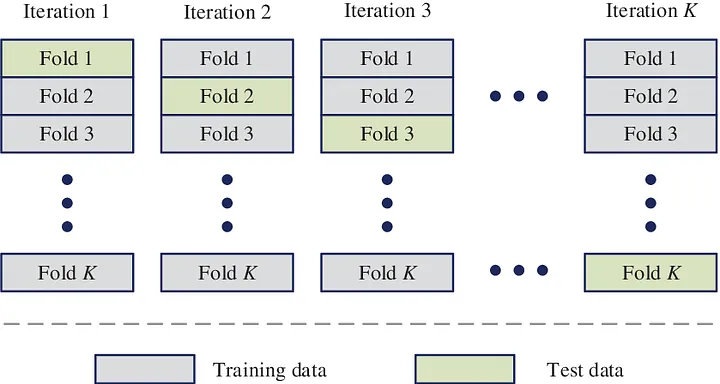

```python
# # Created a common function to fit and predict on a Logistic Regression model for both L1 and L2
def buildAndRunLogisticModels(df_Results, Methodology, X_train,y_train, X_test, y_test ):

  # Logistic Regression
  from sklearn import linear_model
  from sklearn.model_selection import KFold

  num_C = list(np.power(10.0, np.arange(-10, 10)))
  cv_num = KFold(n_splits=10, shuffle=True, random_state=42)
  # CV is used for cross validation in LogisticRegressionCV
  searchCV_l2 = linear_model.LogisticRegressionCV(
          Cs= num_C
          ,penalty='l2'
          ,scoring='roc_auc'
          ,cv=cv_num
          ,random_state=42
          ,max_iter=10000
          ,fit_intercept=True
          ,solver='newton-cg'
          ,tol=10
      )

  searchCV_l1 = linear_model.LogisticRegressionCV(
          Cs=num_C
          ,penalty='l1'
          ,scoring='roc_auc'
          ,cv=cv_num
          ,random_state=42
          ,max_iter=10000
          ,fit_intercept=True
          ,solver='liblinear'
          ,tol=10
      )

  searchCV_l1.fit(X_train, y_train)
  searchCV_l2.fit(X_train, y_train)
  print ('Max auc_roc for l1:', searchCV_l1.scores_[1].mean(axis=0).max())
  print ('Max auc_roc for l2:', searchCV_l2.scores_[1].mean(axis=0).max())

  print("Parameters for l1 regularisations")
  print(searchCV_l1.coef_)
  print(searchCV_l1.intercept_)
  print(searchCV_l1.scores_)

  print("Parameters for l2 regularisations")
  print(searchCV_l2.coef_)
  print(searchCV_l2.intercept_)
  print(searchCV_l2.scores_)


  #find predicted vallues
  y_pred_l1 = searchCV_l1.predict(X_test)
  y_pred_l2 = searchCV_l2.predict(X_test)


  #Find predicted probabilities
  y_pred_probs_l1 = searchCV_l1.predict_proba(X_test)[:,1]
  y_pred_probs_l2 = searchCV_l2.predict_proba(X_test)[:,1]

  # Accuaracy of L2/L1 models
  Accuracy_l2 = metrics.accuracy_score(y_pred=y_pred_l2, y_true=y_test)
  Accuracy_l1 = metrics.accuracy_score(y_pred=y_pred_l1, y_true=y_test)

  print("Accuarcy of Logistic model with l2 regularisation : {0}".format(Accuracy_l2))
  print("Confusion Matrix")
  Plot_confusion_matrix(y_test, y_pred_l2)
  print("classification Report")
  print(classification_report(y_test, y_pred_l2))

  print("Accuarcy of Logistic model with l1 regularisation : {0}".format(Accuracy_l1))
  print("Confusion Matrix")
  Plot_confusion_matrix(y_test, y_pred_l1)
  print("classification Report")
  print(classification_report(y_test, y_pred_l1))

  l2_roc_value = roc_auc_score(y_test, y_pred_probs_l2)
  print("l2 roc_value: {0}" .format(l2_roc_value))
  fpr, tpr, thresholds = metrics.roc_curve(y_test, y_pred_probs_l2)
  threshold = thresholds[np.argmax(tpr-fpr)]
  print("l2 threshold: {0}".format(threshold))

  roc_auc = metrics.auc(fpr, tpr)
  print("ROC for the test dataset",'{:.1%}'.format(roc_auc))
  plt.plot(fpr,tpr,label="Test, auc="+str(roc_auc))
  plt.legend(loc=4)
  plt.show()

  df_Results = df_Results.append(pd.DataFrame({'Methodology': Methodology,'Model': 'Logistic Regression with L2 Regularisation','Accuracy': Accuracy_l2,'roc_value': l2_roc_value,'threshold': threshold}, index=[0]),ignore_index= True)

  l1_roc_value = roc_auc_score(y_test, y_pred_probs_l1)
  print("l1 roc_value: {0}" .format(l1_roc_value))
  fpr, tpr, thresholds = metrics.roc_curve(y_test, y_pred_probs_l1)
  threshold = thresholds[np.argmax(tpr-fpr)]
  print("l1 threshold: {0}".format(threshold))

  roc_auc = metrics.auc(fpr, tpr)
  print("ROC for the test dataset",'{:.1%}'.format(roc_auc))
  plt.plot(fpr,tpr,label="Test, auc="+str(roc_auc))
  plt.legend(loc=4)
  plt.show()

  df_Results = df_Results.append(pd.DataFrame({'Methodology': Methodology,'Model': 'Logistic Regression with L1 Regularisation','Accuracy': Accuracy_l1,'roc_value': l1_roc_value,'threshold': threshold}, index=[0]),ignore_index= True)
  return df_Results
```

## **KNeighborsClassifier**

- KNeighborsClassifier is a class in the scikit-learn library that implements the K-Nearest Neighbors (KNN) algorithm for classification.
- It is a simple and effective algorithm for solving classification problems by finding the closest training examples and assigning the majority class of these nearest neighbors to the test sample. The number of nearest neighbors (k) and the distance metric used can be specified as parameters during model training.

```python
# Created a common function to fit and predict on a KNN model
def buildAndRunKNNModels(df_Results,Methodology, X_train,y_train, X_test, y_test ):

  #create KNN model and fit the model with train dataset
  knn = KNeighborsClassifier(n_neighbors = 5,n_jobs=16)
  knn.fit(X_train,y_train)
  score = knn.score(X_test,y_test)
  print("model score")
  print(score)

  #Accuracy
  y_pred = knn.predict(X_test)
  KNN_Accuracy = metrics.accuracy_score(y_pred=y_pred, y_true=y_test)
  print("Confusion Matrix")
  Plot_confusion_matrix(y_test, y_pred)
  print("classification Report")
  print(classification_report(y_test, y_pred))


  knn_probs = knn.predict_proba(X_test)[:, 1]

  # Calculate roc auc
  knn_roc_value = roc_auc_score(y_test, knn_probs)
  print("KNN roc_value: {0}" .format(knn_roc_value))
  fpr, tpr, thresholds = metrics.roc_curve(y_test, knn_probs)
  threshold = thresholds[np.argmax(tpr-fpr)]
  print("KNN threshold: {0}".format(threshold))

  roc_auc = metrics.auc(fpr, tpr)
  print("ROC for the test dataset",'{:.1%}'.format(roc_auc))
  plt.plot(fpr,tpr,label="Test, auc="+str(roc_auc))
  plt.legend(loc=4)
  plt.show()

  df_Results = df_Results.append(pd.DataFrame({'Methodology': Methodology,'Model': 'KNN','Accuracy': score,'roc_value': knn_roc_value,'threshold': threshold}, index=[0]),ignore_index= True)

  return df_Results
```

**Decision Tree Classifier**

- Predictive Model:
  - Decision Tree Classifier is a supervised learning algorithm used for classification problems. It creates a tree-like model of decisions and their possible consequences, which can be used to predict the class of a new data point. The algorithm starts at the root node and splits the data into different branches based on the values of the features. It continues this process recursively until it reaches the leaf nodes, which represent the final prediction.
- Tree Representation:
  - Decision trees can be easily visualized, which makes them a useful tool for interpreting the relationship between the features and the target variable. The tree representation also makes it possible to understand the logic behind the model's predictions. Each internal node in the tree represents a feature, and each branch represents a possible value of that feature. The leaves of the tree represent the class predictions for the instances that reach that leaf.

```python
# Created a common function to fit and predict on a Tree models for both gini and entropy criteria
def buildAndRunTreeModels(df_Results, Methodology, X_train,y_train, X_test, y_test ):
  #Evaluate Decision Tree model with 'gini' & 'entropy'
  criteria = ['gini', 'entropy']
  scores = {}

  for c in criteria:
      dt = DecisionTreeClassifier(criterion = c, random_state=42)
      dt.fit(X_train, y_train)
      y_pred = dt.predict(X_test)
      test_score = dt.score(X_test, y_test)
      tree_preds = dt.predict_proba(X_test)[:, 1]
      tree_roc_value = roc_auc_score(y_test, tree_preds)
      scores = test_score
      print(c + " score: {0}" .format(test_score))
      print("Confusion Matrix")
      Plot_confusion_matrix(y_test, y_pred)
      print("classification Report")
      print(classification_report(y_test, y_pred))
      print(c + " tree_roc_value: {0}" .format(tree_roc_value))
      fpr, tpr, thresholds = metrics.roc_curve(y_test, tree_preds)
      threshold = thresholds[np.argmax(tpr-fpr)]
      print("Tree threshold: {0}".format(threshold))
      roc_auc = metrics.auc(fpr, tpr)
      print("ROC for the test dataset",'{:.1%}'.format(roc_auc))
      plt.plot(fpr,tpr,label="Test, auc="+str(roc_auc))
      plt.legend(loc=4)
      plt.show()

      df_Results = df_Results.append(pd.DataFrame({'Methodology': Methodology,'Model': 'Tree Model with {0} criteria'.format(c),'Accuracy': test_score,'roc_value': tree_roc_value,'threshold': threshold}, index=[0]),ignore_index= True)

  return df_Results
```

**Random Forest Classifier**

- Ensemble Method:
  - Random Forest Classifier is an ensemble learning method for classification problems. It creates multiple decision trees and combines their predictions to produce a final output. This helps to reduce overfitting, which is a common issue with decision trees. The idea behind this method is to train multiple trees on random subsets of the data, and average their predictions to produce a more robust result.
- Bagging and Feature Selection:
  - Random Forest Classifier is based on two main concepts: Bagging (Bootstrapped Aggregating) and feature selection. Bagging is a resampling technique used to create multiple training sets from the original data. In Random Forest Classifier, each decision tree is trained on a different bootstrapped sample of the data. Feature selection is used to randomly select a subset of features for each split, which helps to reduce the correlation between trees and improve the overall accuracy of the model. The combination of bagging and feature selection results in a strong and reliable prediction model.

```python
# Created a common function to fit and predict on a Random Forest model
def buildAndRunRandomForestModels(df_Results, Methodology, X_train,y_train, X_test, y_test ):
  #Evaluate Random Forest model

  # Create the model with 100 trees
  RF_model = RandomForestClassifier(n_estimators=100,
                                bootstrap = True,
                                max_features = 'sqrt', random_state=42)
  # Fit on training data
  RF_model.fit(X_train, y_train)
  RF_test_score = RF_model.score(X_test, y_test)
  RF_model.predict(X_test)

  print('Model Accuracy: {0}'.format(RF_test_score))


  # Actual class predictions
  rf_predictions = RF_model.predict(X_test)

  print("Confusion Matrix")
  Plot_confusion_matrix(y_test, rf_predictions)
  print("classification Report")
  print(classification_report(y_test, rf_predictions))

  # Probabilities for each class
  rf_probs = RF_model.predict_proba(X_test)[:, 1]

  # Calculate roc auc
  roc_value = roc_auc_score(y_test, rf_probs)

  print("Random Forest roc_value: {0}" .format(roc_value))
  fpr, tpr, thresholds = metrics.roc_curve(y_test, rf_probs)
  threshold = thresholds[np.argmax(tpr-fpr)]
  print("Random Forest threshold: {0}".format(threshold))
  roc_auc = metrics.auc(fpr, tpr)
  print("ROC for the test dataset",'{:.1%}'.format(roc_auc))
  plt.plot(fpr,tpr,label="Test, auc="+str(roc_auc))
  plt.legend(loc=4)
  plt.show()

  df_Results = df_Results.append(pd.DataFrame({'Methodology': Methodology,'Model': 'Random Forest','Accuracy': RF_test_score,'roc_value': roc_value,'threshold': threshold}, index=[0]),ignore_index= True)

  return df_Results
```

**XGBoost (eXtreme Gradient Boosting) Classifier**

- Gradient Boosting:
  - XGBoost (eXtreme Gradient Boosting) Classifier is an implementation of gradient boosting for classification problems. It is an advanced version of gradient boosting that is designed to handle large datasets and high-dimensional features. XGBoost Classifier trains weak decision trees in a sequential manner, using the errors from the previous tree to improve the predictions of the next tree. This process continues until a set number of trees have been trained, or a specified stopping criterion is met.
- Scalability and Performance:
  - XGBoost Classifier is known for its scalability and performance. It uses parallel processing and efficient algorithms to train models quickly and accurately. It also includes a number of optimization techniques, such as regularization, to help prevent overfitting and improve the generalization performance of the model. XGBoost Classifier has won several machine learning competitions and is widely used in industry due to its ability to handle large datasets and produce accurate predictions.

```python
# Created a common function to fit and predict on a XGBoost model
def buildAndRunXGBoostModels(df_Results, Methodology,X_train,y_train, X_test, y_test ):
  #Evaluate XGboost model
  XGBmodel = XGBClassifier(random_state=42)
  XGBmodel.fit(X_train, y_train)
  y_pred = XGBmodel.predict(X_test)

  XGB_test_score = XGBmodel.score(X_test, y_test)
  print('Model Accuracy: {0}'.format(XGB_test_score))

  print("Confusion Matrix")
  Plot_confusion_matrix(y_test, y_pred)
  print("classification Report")
  print(classification_report(y_test, y_pred))
  # Probabilities for each class
  XGB_probs = XGBmodel.predict_proba(X_test)[:, 1]

  # Calculate roc auc
  XGB_roc_value = roc_auc_score(y_test, XGB_probs)

  print("XGboost roc_value: {0}" .format(XGB_roc_value))
  fpr, tpr, thresholds = metrics.roc_curve(y_test, XGB_probs)
  threshold = thresholds[np.argmax(tpr-fpr)]
  print("XGBoost threshold: {0}".format(threshold))
  roc_auc = metrics.auc(fpr, tpr)
  print("ROC for the test dataset",'{:.1%}'.format(roc_auc))
  plt.plot(fpr,tpr,label="Test, auc="+str(roc_auc))
  plt.legend(loc=4)
  plt.show()

  df_Results = df_Results.append(pd.DataFrame({'Methodology': Methodology,'Model': 'XGBoost','Accuracy': XGB_test_score,'roc_value': XGB_roc_value,'threshold': threshold}, index=[0]),ignore_index= True)

  return df_Results
```

**Support Vector Classifier (SVC)**

- Support Vector Machines:
  - Support Vector Classifier (SVC) is a type of Support Vector Machine (SVM) algorithm used for classification problems. SVC is a linear classifier that finds the hyperplane that best separates the data into classes. The goal of the algorithm is to maximize the margin between the hyperplane and the closest data points, called support vectors, which are used to define the boundary between the classes.
- Kernel Trick:
  - SVC can also be used for non-linearly separable data by using a technique called the kernel trick. The kernel trick transforms the data into a high-dimensional feature space, where a linear boundary can be found. The transformation is performed implicitly, so the user does not need to explicitly perform the calculation. This makes SVC a versatile algorithm that can be used for a wide range of classification problems, including both linearly separable and non-linearly separable data.
- Note: SVC can also be used for regression problems, in which case it is called Support Vector Regression (SVR).

```python
# Created a common function to fit and predict on a SVM model
def buildAndRunSVMModels(df_Results, Methodology, X_train,y_train, X_test, y_test ):
  #Evaluate SVM model with sigmoid kernel  model
  from sklearn.svm import SVC
  from sklearn.metrics import accuracy_score
  from sklearn.metrics import roc_auc_score

  clf = SVC(kernel='sigmoid', random_state=42)
  clf.fit(X_train,y_train)
  y_pred_SVM = clf.predict(X_test)
  SVM_Score = accuracy_score(y_test,y_pred_SVM)
  print("accuracy_score : {0}".format(SVM_Score))
  print("Confusion Matrix")
  Plot_confusion_matrix(y_test, y_pred_SVM)
  print("classification Report")
  print(classification_report(y_test, y_pred_SVM))

  # Run classifier
  classifier = SVC(kernel='sigmoid' , probability=True)
  svm_probs = classifier.fit(X_train, y_train).predict_proba(X_test)[:, 1]

  # Calculate roc auc
  roc_value = roc_auc_score(y_test, svm_probs)

  print("SVM roc_value: {0}" .format(roc_value))
  fpr, tpr, thresholds = metrics.roc_curve(y_test, svm_probs)
  threshold = thresholds[np.argmax(tpr-fpr)]
  print("SVM threshold: {0}".format(threshold))
  roc_auc = metrics.auc(fpr, tpr)
  print("ROC for the test dataset",'{:.1%}'.format(roc_auc))
  plt.plot(fpr,tpr,label="Test, auc="+str(roc_auc))
  plt.legend(loc=4)
  plt.show()

  df_Results = df_Results.append(pd.DataFrame({'Methodology': Methodology,'Model': 'SVM','Accuracy': SVM_Score,'roc_value': roc_value,'threshold': threshold}, index=[0]),ignore_index= True)

  return df_Results
```

**ANN**

```python
# Created a common function to fit and predict on a SVM model
def buildAndgetmetricsANN(df_Results, Methodology, X_train,y_train, X_test, y_test ):
  from sklearn.metrics import accuracy_score
  from sklearn.metrics import roc_auc_score

  ann = Sequential([Dense(input_dim = 30, units = 16, activation = 'relu'),
  Dense(units = 24, activation = 'relu'),
  Dropout(0.5),
  Dense(units = 20, activation = 'relu'),
  Dense(units = 24, activation = 'relu'),
  Dense(units =1, activation = 'sigmoid'),])

  ann.compile(optimizer = 'adam', loss = 'binary_crossentropy', metrics = ['accuracy'])
  ann.fit(X_train, y_train, batch_size = 15, epochs = 5)

  ann.fit(X_train,y_train)
  y_pred_ann_prob = ann.predict(X_test)
  y_pred_ann = np.where(y_pred_ann_prob>0.5,1,0)
  ANN_Score = accuracy_score(y_test,y_pred_ann)
  print("accuracy_score : {0}".format(ANN_Score))
  print("Confusion Matrix")
  Plot_confusion_matrix(y_test, y_pred_ann)
  print("classification Report")
  print(classification_report(y_test, y_pred_ann))

  # Run classifier
  # classifier = SVC(kernel='sigmoid' , probability=True)
  # svm_probs = classifier.fit(X_train, y_train).predict_proba(X_test)[:, 1]

  # Calculate roc auc
  roc_value = roc_auc_score(y_test, y_pred_ann_prob)

  print("ANN roc_value: {0}" .format(roc_value))
  fpr, tpr, thresholds = metrics.roc_curve(y_test, y_pred_ann_prob)
  threshold = thresholds[np.argmax(tpr-fpr)]
  print("ANN threshold: {0}".format(threshold))
  roc_auc = metrics.auc(fpr, tpr)
  print("ROC for the test dataset",'{:.1%}'.format(roc_auc))
  plt.plot(fpr,tpr,label="Test, auc="+str(roc_auc))
  plt.legend(loc=4)
  plt.show()

  df_Results = df_Results.append(pd.DataFrame({'Methodology': Methodology,'Model': 'ANN','Accuracy': ANN_Score,'roc_value': roc_value,'threshold': threshold}, index=[0]),ignore_index= True)

  return df_Results
```

- Build different models on the imbalanced dataset and see the result